# 변분 기댓값-최대화(VEM)를 이용한 커널 밀도 추정

Taenyoung Lee

2025-08-27

## 1 **초록 (Abstract)**

비모수적 밀도 추정, 특히 커널 기반 모델은 복잡한 데이터 분포를 모델링하는 데 강력한 유연성을 제공한다. 그러나 이러한 모델의 성능은 커널 대역폭($\sigma$) 및 정규화 강도($\lambda$)와 같은 핵심 하이퍼파라미터의 선택에 크게 좌우된다. 전통적으로 이러한 파라미터는 교차 검증(Cross-Validation)과 같은 계산 비용이 많이 드는 탐색적 절차를 통해 최적화된다. 본 문서는 이러한 비효율적인 탐색 과정을 대체하기 위해, 변분 기댓값-최대화(Variational Expectation-Maximization, VEM) 프레임워크를 기반으로 한 완전 베이지안 접근법을 제시한다. 스코어 매칭(Score Matching) 목적 함수를 가능도(Likelihood)로 활용하고, 모델 파라미터에 대한 계층적 베이지안 모델을 구축함으로써, VEM 알고리즘이 데이터로부터 직접 하이퍼파라미터를 추론하는 과정을 유도한다. 이 통합된 최적화 프레임워크는 계산 효율성을 극대화할 뿐만 아니라, 증거 하한(ELBO) 최대화라는 단일 원칙하에 모든 파라미터를 학습하는 수학적 정합성을 보장한다. 최종적으로 R을 이용한 수치적 실험을 통해 제안된 VEM 알고리즘이 안정적으로 수렴하며 데이터의 기저 분포를 성공적으로 추정함을 실증적으로 검증한다.

## 2 **1. 서론 (Introduction)**

확률 밀도 함수를 추정하는 것은 통계적 추론과 기계 학습의 근본적인 과제이다. 커널 지수족(Kernel Exponential Family)과 같은 커널 기반의 비모수적 모델은 임의의 복잡한 분포를 근사할 수 있는 높은 표현력을 가지고 있어 널리 사용된다. 그러나 이 모델의 실제적 효용성은 **모델의 복잡도를 제어하는 두 가지 주요 하이퍼파라미터**에 의해 결정된다.

- **커널 대역폭 ($\sigma$):** 추정된 밀도 함수의 평활도(smoothness)를 결정한다. 과소 추정 시 과적합(overfitting)을, 과대 추정 시 과소적합(underfitting)을 야기한다.
- **정규화 강도 ($\lambda$):** 모델 가중치의 크기를 제한하여 과적합을 방지하는 역할을 한다. 베이지안 관점에서 이는 가중치에 대한 사전 분포의 정밀도(precision)와 관련된다.

전통적으로 이들 하이퍼파라미터의 최적 조합은 **교차 검증(Cross-Validation, CV)**에 기반한 그리드 탐색(grid search)을 통해 결정된다. 이 방식은 직관적이나, 후보 파라미터 공간 전체에 대한 반복적인 모델 학습 및 평가를 요구하므로 막대한 계산 자원을 소모하는 단점이 있다.

본 문서는 이러한 문제를 해결하기 위해, **변분 기댓값-최대화(VEM) 알고리즘**에 기반한 접근법을 제안한다. VEM은 하이퍼파라미터를 탐색의 대상이 아닌, 모델의 일부로 간주하여 데이터로부터 직접 학습하는 베이지안 추론 프레임워크이다. 이를 통해 전체 튜닝 과정을 단일 최적화 문제로 변환하여 계산 효율성을 획기적으로 개선하고, 원칙에 입각한 자동화된 모델링을 구현하는 것을 목표로 한다.

## 3 **2. 방법론: 베이지안 추론 프레임워크 (Methodology: A Bayesian Inference Framework)**

### 3.1 **2.1. 스코어 매칭 목적 함수 (Score Matching Objective Function)**

커널 지수족 모델의 로그 확률 밀도는 $\log p_\theta(x) = \mathbf{w}^\top \bm{\phi}_\sigma(x) - A(\theta)$로 표현된다. 여기서 $\theta = {\mathbf{w}, \sigma}$는 모델 파라미터, $\bm{\phi}_\sigma(x)$는 커널 기저 함수 벡터, 그리고 $A(\theta) = \log \int \exp(\mathbf{w}^\top \bm{\phi}_\sigma(x)) dx$는 정규화 상수(partition function)이다. $A(\theta)$는 전체 데이터 공간에 대한 적분을 포함하므로 직접적인 계산이 불가능(intractable)하다.

이 문제를 해결하기 위해 Hyvärinen (2005)이 제안한 **스코어 매칭(Score Matching)** 기법을 도입한다. 스코어 매칭은 확률 밀도 자체를 직접 맞추는 대신, 밀도 함수의 그래디언트(score function, $\nabla_x \log p(x)$)를 일치시키는 것을 목표로 한다. 이 목적 함수를 유도하는 과정에서 $A(\theta)$ 항이 상쇄되어, 다루기 쉬운 형태로 변환된다. 최종적으로 우리가 최소화할 스코어 매칭 목적 함수는 가중치 $\mathbf{w}$에 대한 다음과 같은 **이차 형식(quadratic form)**으로 귀결된다.

$$J(\mathbf{w};\sigma) = \frac12
\mathbf{w}^\top K_\sigma \mathbf{w} - \mathbf{b_\sigma}^\top
\mathbf{w}$$

여기서 행렬 $K_\sigma$와 벡터 $\mathbf{b}_\sigma$는 데이터와 커널 함수에만 의존하는 항이다. 목적 함수가 $\mathbf{w}$에 대해 볼록(convex)한 이차식 형태라는 점은 이후 베이지안 추론 과정에서 해석적 용이성을 제공하는 핵심적인 특징이 된다.

### 3.2 **2.2. 계층적 베이지안 모델링 (Hierarchical Bayesian Modeling)**

VEM 프레임워크를 적용하기 위해 다음과 같은 계층적 베이지안 모델을 설정한다.

1. **가능도 함수 (Likelihood):** 스코어 매칭 목적 함수 $J(\mathbf{w};\sigma)$를 음의 로그 가능도로 사용하여 가능도 함수를 정의한다.
   $$p(D \mid \mathbf{w}, \sigma, \beta) \propto \exp(
   -\beta J(\mathbf{w};\sigma) )$$
   여기서 $\beta$는 모델의 정밀도(precision) 파라미터로, 본 문서에서는 계산의 안정성을 위해 1로 고정한다.
2. **사전 분포 (Prior):** 모델의 과적합을 방지하기 위해 가중치 $\mathbf{w}$에 대해 평균이 0인 가우시안 사전 분포를 가정한다. 이는 전통적인 L2 정규화(Ridge Regression)에 해당한다.
   $$p(\mathbf{w} \mid
   \tau) = \mathcal{N}(\mathbf{w} \mid \mathbf{0}, \tau^2 I)$$
   하이퍼파라미터 $\tau^2$는 가중치의 분산을 제어하며, 이의 역수 $\tau^{-2}$는 정규화 강도 $\lambda$의 역할을 수행한다.

우리의 최종 목표는 주어진 데이터 $D$와 하이퍼파라미터 $\theta = {\sigma, \tau}$ 하에서 가중치의 사후 분포 $p(\mathbf{w} \mid D, \theta)$를 추론하고, 동시에 데이터의 증거(evidence) $p(D \mid \theta)$를 최대화하는 최적의 $\theta$를 찾는 것이다.

### 3.3 **2.3. 변분 추론과 증거 하한 (Variational Inference and the ELBO)**

사후 분포와 모델 증거는 모두 직접 계산이 어렵기 때문에, 변분 추론(Variational Inference)을 통해 이 문제에 대한 근사적 해법을 찾는다. 먼저, 다루기 쉬운 가우시안 분포 $q(\mathbf{w}) = \mathcal{N}(\mathbf{w} \mid \mathbf{m}, S)$를 도입하여 실제 사후 분포를 근사한다.

변분 추론의 목표는 $q(\mathbf{w})$와 실제 사후 분포 $p(\mathbf{w} \mid D, \theta)$ 사이의 **쿨백-라이블러 발산(Kullback-Leibler Divergence)**을 최소화하는 것이다. 이는 로그 모델 증거($\log p(D \mid \theta)$)의 하한(Lower Bound)인 **증거 하한(ELBO, $\mathcal{L}$)**을 최대화하는 것과 수학적으로 동일하다.

$$\mathcal{L}(q, \theta) =
\mathbb{E}_q[\log p(D, \mathbf{w} \mid \theta)] - \mathbb{E}_q[\log
q(\mathbf{w})]$$

ELBO는 모델이 데이터를 얼마나 잘 설명하는지를 나타내는 **데이터 적합도 항**과, 근사 사후 분포의 복잡도를 제어하는 **엔트로피 항** 사이의 균형을 맞추는 목적 함수로 해석할 수 있다. VEM 알고리즘은 바로 이 ELBO를 최대화하기 위해 파라미터들을 반복적으로 업데이트한다.

## 4 **3. 변분 기댓값-최대화(VEM) 알고리즘**

VEM 알고리즘은 ELBO를 최대화하기 위해 **E(Expectation) 단계**와 **M(Maximization) 단계**를 번갈아 수행한다.

### 4.1 **3.1. E-단계: 변분 파라미터 최적화 (Inference)**

E-단계에서는 하이퍼파라미터 ${\sigma, \tau}$를 고정한 상태에서, ELBO를 변분 파라미터 ${\mathbf{m}, S}$에 대해 최대화한다. 이는 $q(\mathbf{w})$가 현재 하이퍼파라미터 조건 하에서 실제 사후 분포에 가장 근접하도록 업데이트하는 과정이며, 다음과 같은 해석적 해(analytical solution)를 갖는다.

- **공분산 $S$ 업데이트:**
  $$S \leftarrow (\beta
  K_\sigma + \tau^{-2} I)^{-1}$$
- **평균 $\mathbf{m}$ 업데이트:**
  $$\mathbf{m} \leftarrow
  \beta S \mathbf{b}_\sigma$$

### 4.2 **3.2. M-단계: 하이퍼파라미터 최적화 (Learning)**

M-단계에서는 E-단계에서 구한 변분 파라미터 ${\mathbf{m}, S}$를 고정한 후, ELBO를 하이퍼파라미터 ${\sigma, \tau}$에 대해 최대화한다.

- **$\tau$ (정규화) 업데이트:** ELBO를 $\tau^2$에 대해 최대화하면 다음과 같은 해석적 업데이트 규칙을 얻는다. 이는 데이터가 요구하는 최적의 정규화 강도를 매 반복마다 자동으로 결정하는 과정이다.
  $$\tau^2 \leftarrow \frac{\mathrm{tr}(S) +
  \|\mathbf{m}\|^2}{M}$$
  여기서 $M$은 기저 함수의 개수이다.
- **$\sigma$ (커널 대역폭) 업데이트:** $\sigma$에 대한 최적화는 닫힌 해가 존재하지 않으므로 **경사 상승법(Gradient Ascent)**을 사용한다. ELBO를 $\sigma$에 대해 미분한 그래디언트 $\frac{\partial \mathcal{L}}{\partial \sigma}$를 계산하여 $\sigma$를 업데이트한다.
  $$\sigma \leftarrow \sigma + \eta_\sigma
  \frac{\partial \mathcal{L}}{\partial \sigma}$$
  여기서 $\eta_\sigma$는 학습률(learning rate)이다.

이 두 단계를 수렴할 때까지 반복하면, 모든 파라미터들이 ELBO를 공동으로 최대화하는 값으로 수렴하게 된다.

## 5 **4. 실험 결과 및 분석 (Empirical Validation)**

### 5.1 **4.1. 실험 설계 및 구현**

제안된 VEM 알고리즘의 유효성을 검증하기 위해, 잘 알려진 이중 봉우리(bimodal) 분포를 갖는 2차원 가우시안 혼합 모델(Gaussian Mixture Model)로부터 200개의 데이터를 생성하여 실험을 진행했다. 알고리즘의 수렴 과정을 관찰하기 위해 매 반복마다 ELBO, 커널 대역폭($\sigma$), 정규화 파라미터($\tau$)의 변화를 기록했다.

```r
library(mvtnorm)
library(ggplot2)
library(gridExtra)

# 데이터 생성
n  <- 200
pi <- c(0.55, 0.45)
mu <- list(c(-1, -0.5), c(2, 1.2))
S1 <- matrix(c(0.6, 0.3, 0.3, 0.8), 2, 2)
S2 <- matrix(c(0.5, -0.2, -0.2, 0.5), 2, 2)
z  <- rbinom(n, size = 1, prob = pi[2]) + 1
X_data <- matrix(NA, n, 2)
X_data[z==1,] <- rmvnorm(sum(z==1), mean = mu[[1]], sigma = S1)
X_data[z==2,] <- rmvnorm(sum(z==2), mean = mu[[2]], sigma = S2)
dat <- data.frame(x1 = X_data[,1], x2 = X_data[,2])

# 커널 및 도함수 정의
rbf_kernel <- function(x, y, sigma) exp(-sum((x - y)^2) / (2 * sigma^2))
grad_x_rbf <- function(x, y, sigma) -rbf_kernel(x, y, sigma) * (x - y) / sigma^2
lap_x_rbf <- function(x, y, sigma) {
  sq_dist <- sum((x - y)^2); d <- length(x)
  rbf_kernel(x, y, sigma) * (sq_dist / sigma^4 - d / sigma^2)
}
grad_sigma_grad_x_rbf <- function(x, y, sigma) {
  rbf <- rbf_kernel(x, y, sigma); sq_dist <- sum((x-y)^2)
  (-rbf * sq_dist / sigma^5 + 2 * rbf / sigma^3) * (x - y)
}
grad_sigma_lap_x_rbf <- function(x, y, sigma) {
  rbf <- rbf_kernel(x, y, sigma); sq_dist <- sum((x - y)^2); d <- length(x)
  grad_sigma_rbf <- rbf * sq_dist / sigma^3
  term1 <- grad_sigma_rbf * (sq_dist / sigma^4 - d/sigma^2)
  term2 <- rbf * (-4*sq_dist/sigma^5 + 2*d/sigma^3)
  return(term1 + term2)
}
```

```r
# K, b 및 sigma에 대한 도함수들을 계산하는 함수
compute_derivatives <- function(X, basis, sigma) {
  n <- nrow(X); M <- nrow(basis); D <- ncol(X)
  K_sigma <- matrix(0, M, M); b_sigma <- numeric(M)
  dK_dsigma <- matrix(0, M, M); db_dsigma <- numeric(M)

  for (i in 1:n) {
    J_i <- matrix(0, D, M); dJ_dsigma_i <- matrix(0, D, M)
    H_i_row <- numeric(M); dH_dsigma_i_row <- numeric(M)
    for (j in 1:M) {
      J_i[, j] <- grad_x_rbf(X[i, ], basis[j, ], sigma)
      dJ_dsigma_i[, j] <- grad_sigma_grad_x_rbf(X[i, ], basis[j, ], sigma)
      H_i_row[j] <- lap_x_rbf(X[i, ], basis[j, ], sigma)
      dH_dsigma_i_row[j] <- grad_sigma_lap_x_rbf(X[i, ], basis[j, ], sigma)
    }
    K_sigma <- K_sigma + t(J_i) %*% J_i
    b_sigma <- b_sigma - H_i_row
    dK_dsigma <- dK_dsigma + (t(dJ_dsigma_i) %*% J_i + t(J_i) %*% dJ_dsigma_i)
    db_dsigma <- db_dsigma - dH_dsigma_i_row
  }
  return(list(K = K_sigma/n, b = b_sigma/n, dK_dsigma = dK_dsigma/n, db_dsigma = db_dsigma/n))
}

# VEM 알고리즘 주 함수 (ELBO 계산식 수정됨)
run_vem_final <- function(X_data, basis_pts, n_iters = 100, lr_sigma = 1e-5) {
  M <- nrow(basis_pts)
  # 하이퍼파라미터 초기화: 우리의 첫 번째 가정
  sigma <- 1.0; tau2 <- 1.0; beta <- 1.0
  # 기록용 데이터프레임
  history <- data.frame(iter = 1:n_iters, elbo = NA, sigma = NA, tau = NA)

  cat("VEM 알고리즘 (최종 버전) 시작...\n")
  for (iter in 1:n_iters) {
    # M-단계를 위해 필요한 모든 도함수들을 미리 계산
    derivs <- compute_derivatives(X_data, basis_pts, sigma)
    K_sigma <- derivs$K; b_sigma <- derivs$b

    # --- E-단계: 추론 (Inference) ---
    # 왜? 현재의 가정(sigma, tau) 하에서 데이터가 말해주는 w의 최선의 분포(m, S)를 찾기 위해
    S <- solve(beta * K_sigma + (1/tau2) * diag(M) + diag(1e-8, M))
    m <- beta * S %*% b_sigma

    # --- M-단계: 학습 (Learning) ---
    # 왜? 방금 추론한 결과를 바탕으로, 더 나은 가정을 찾기 위해

    # 1. tau 업데이트: 정규화 강도 자동 조절
    # 왜? "데이터를 보니 w가 이 정도는 복잡해야 했구나" -> "그럼 내 편견(tau)을 이 현실에 맞게 수정하자"
    tau2 <- (sum(diag(S)) + sum(m^2)) / M

    # 2. sigma 업데이트: 커널 대역폭 자동 조절
    # 왜? "내 렌즈(sigma)를 이렇게 바꾸니 전체 설명력(ELBO)이 더 좋아지네?" -> "그럼 그 방향으로 조금 움직이자"
    grad_L_sigma <- -0.5 * beta * (sum(diag(derivs$dK_dsigma %*% S)) + t(m) %*% derivs$dK_dsigma %*% m) +
                    beta * t(derivs$db_dsigma) %*% m
    sigma <- sigma + lr_sigma * grad_L_sigma
    sigma <- max(sigma, 0.01) # 물리적으로 의미있는 값으로 유지

    # --- 모니터링: 정확한 ELBO 값 계산 ---
    # 왜? 우리 모델이 올바른 방향으로 학습하고 있는지(ELBO가 증가하는지) 확인하기 위해
    log_det_S <- determinant(S, logarithm = TRUE)$modulus[1]

    # ELBO = E_q[log p(D,w)] - E_q[log q(w)]
    log_likelihood_term <- -0.5*beta*(sum(diag(K_sigma %*% S)) + t(m)%*%K_sigma%*%m) + beta * t(b_sigma)%*%m
    log_prior_term <- -0.5 * (M * log(tau2) + (sum(diag(S)) + sum(m^2))/tau2)
    entropy_term <- 0.5 * log_det_S
    elbo <- log_likelihood_term + log_prior_term + entropy_term

    # 결과 기록
    history[iter, ] <- c(iter, elbo, sigma, sqrt(tau2))
    if (iter %% 10 == 0) cat(sprintf("  Iter %d: ELBO=%.2f, sigma=%.3f, tau=%.3f\n", iter, elbo, sigma, sqrt(tau2)))
  }
  cat("VEM 알고리즘 종료.\n")
  return(list(m = m, S = S, final_params = c(sigma, sqrt(tau2), beta), history = history))
}

# VEM 실행
basis_pts <- X_data
vem_results <- run_vem_final(X_data, basis_pts, n_iters = 1000, lr_sigma = 1e-5)
```

```
## VEM 알고리즘 (최종 버전) 시작...
##   Iter 10: ELBO=-103.10, sigma=1.000, tau=0.881
##   Iter 20: ELBO=-102.59, sigma=1.001, tau=0.787
##   Iter 30: ELBO=-102.20, sigma=1.001, tau=0.713
##   Iter 40: ELBO=-101.89, sigma=1.001, tau=0.652
##   Iter 50: ELBO=-101.64, sigma=1.002, tau=0.603
##   Iter 60: ELBO=-101.44, sigma=1.002, tau=0.562
##   Iter 70: ELBO=-101.27, sigma=1.002, tau=0.527
##   Iter 80: ELBO=-101.14, sigma=1.002, tau=0.497
##   Iter 90: ELBO=-101.02, sigma=1.002, tau=0.471
##   Iter 100: ELBO=-100.93, sigma=1.003, tau=0.449
##   Iter 110: ELBO=-100.85, sigma=1.003, tau=0.429
##   Iter 120: ELBO=-100.78, sigma=1.003, tau=0.412
##   Iter 130: ELBO=-100.72, sigma=1.003, tau=0.396
##   Iter 140: ELBO=-100.67, sigma=1.003, tau=0.382
##   Iter 150: ELBO=-100.62, sigma=1.003, tau=0.370
##   Iter 160: ELBO=-100.58, sigma=1.003, tau=0.358
##   Iter 170: ELBO=-100.55, sigma=1.003, tau=0.348
##   Iter 180: ELBO=-100.52, sigma=1.003, tau=0.338
##   Iter 190: ELBO=-100.49, sigma=1.003, tau=0.329
##   Iter 200: ELBO=-100.46, sigma=1.003, tau=0.321
##   Iter 210: ELBO=-100.44, sigma=1.004, tau=0.314
##   Iter 220: ELBO=-100.42, sigma=1.004, tau=0.306
##   Iter 230: ELBO=-100.40, sigma=1.004, tau=0.300
##   Iter 240: ELBO=-100.38, sigma=1.004, tau=0.294
##   Iter 250: ELBO=-100.37, sigma=1.004, tau=0.288
##   Iter 260: ELBO=-100.35, sigma=1.004, tau=0.282
##   Iter 270: ELBO=-100.34, sigma=1.004, tau=0.277
##   Iter 280: ELBO=-100.33, sigma=1.004, tau=0.272
##   Iter 290: ELBO=-100.32, sigma=1.004, tau=0.268
##   Iter 300: ELBO=-100.30, sigma=1.004, tau=0.263
##   Iter 310: ELBO=-100.29, sigma=1.004, tau=0.259
##   Iter 320: ELBO=-100.28, sigma=1.004, tau=0.255
##   Iter 330: ELBO=-100.28, sigma=1.004, tau=0.251
##   Iter 340: ELBO=-100.27, sigma=1.004, tau=0.248
##   Iter 350: ELBO=-100.26, sigma=1.004, tau=0.244
##   Iter 360: ELBO=-100.25, sigma=1.004, tau=0.241
##   Iter 370: ELBO=-100.24, sigma=1.004, tau=0.238
##   Iter 380: ELBO=-100.24, sigma=1.004, tau=0.235
##   Iter 390: ELBO=-100.23, sigma=1.004, tau=0.232
```

[output cut: 47 more lines]

```
##   Iter 870: ELBO=-100.10, sigma=1.005, tau=0.158
##   Iter 880: ELBO=-100.10, sigma=1.005, tau=0.157
##   Iter 890: ELBO=-100.10, sigma=1.005, tau=0.157
##   Iter 900: ELBO=-100.10, sigma=1.005, tau=0.156
##   Iter 910: ELBO=-100.10, sigma=1.005, tau=0.155
##   Iter 920: ELBO=-100.10, sigma=1.005, tau=0.154
##   Iter 930: ELBO=-100.10, sigma=1.005, tau=0.153
##   Iter 940: ELBO=-100.10, sigma=1.005, tau=0.153
##   Iter 950: ELBO=-100.09, sigma=1.005, tau=0.152
##   Iter 960: ELBO=-100.09, sigma=1.005, tau=0.151
##   Iter 970: ELBO=-100.09, sigma=1.005, tau=0.150
##   Iter 980: ELBO=-100.09, sigma=1.005, tau=0.150
##   Iter 990: ELBO=-100.09, sigma=1.005, tau=0.149
##   Iter 1000: ELBO=-100.09, sigma=1.005, tau=0.148
## VEM 알고리즘 종료.
```

### 5.2 **4.2. 수렴 분석 및 밀도 추정 결과**

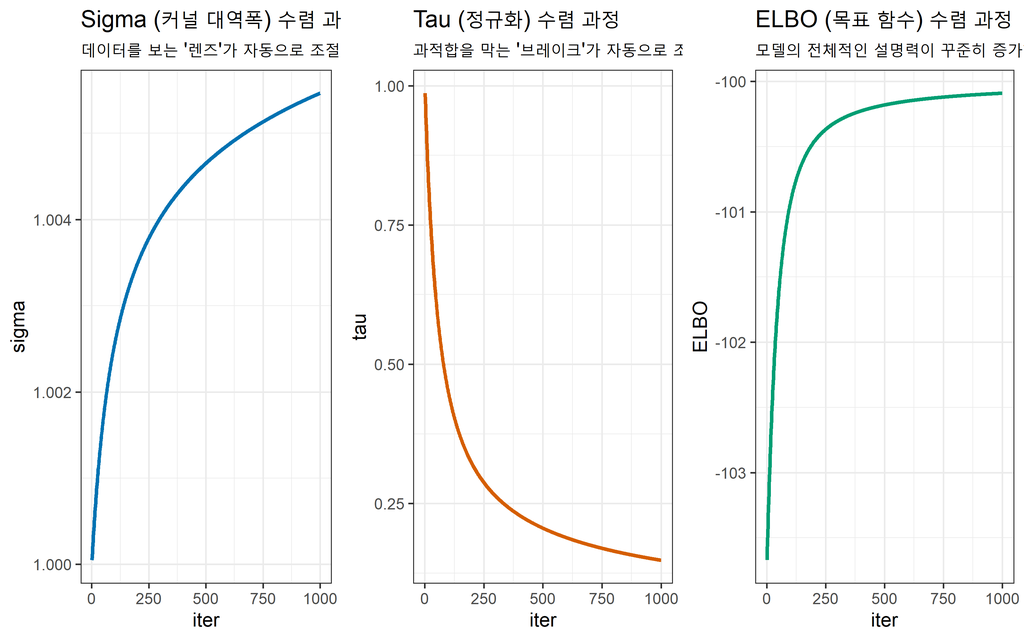

```r
history <- na.omit(vem_results$history) # 첫 반복에서 NaN이 발생할 수 있는 경우 제외

# ELBO 및 하이퍼파라미터 수렴 과정 시각화
p1 <- ggplot(history, aes(x = iter, y = sigma)) + geom_line(color="#0072B2", size=1) + labs(title = "Sigma (커널 대역폭) 수렴 과정", subtitle="데이터를 보는 '렌즈'가 자동으로 조절됨", y = "sigma") + theme_bw()
p2 <- ggplot(history, aes(x = iter, y = tau)) + geom_line(color="#D55E00", size=1) + labs(title = "Tau (정규화) 수렴 과정", subtitle="과적합을 막는 '브레이크'가 자동으로 조절됨", y = "tau") + theme_bw()
p3 <- ggplot(history, aes(x = iter, y = elbo)) + geom_line(color="#009E73", size=1) + labs(title = "ELBO (목표 함수) 수렴 과정", subtitle="모델의 전체적인 설명력이 꾸준히 증가함", y = "ELBO") + theme_bw()

grid.arrange(p1, p2, p3, ncol = 3)
```

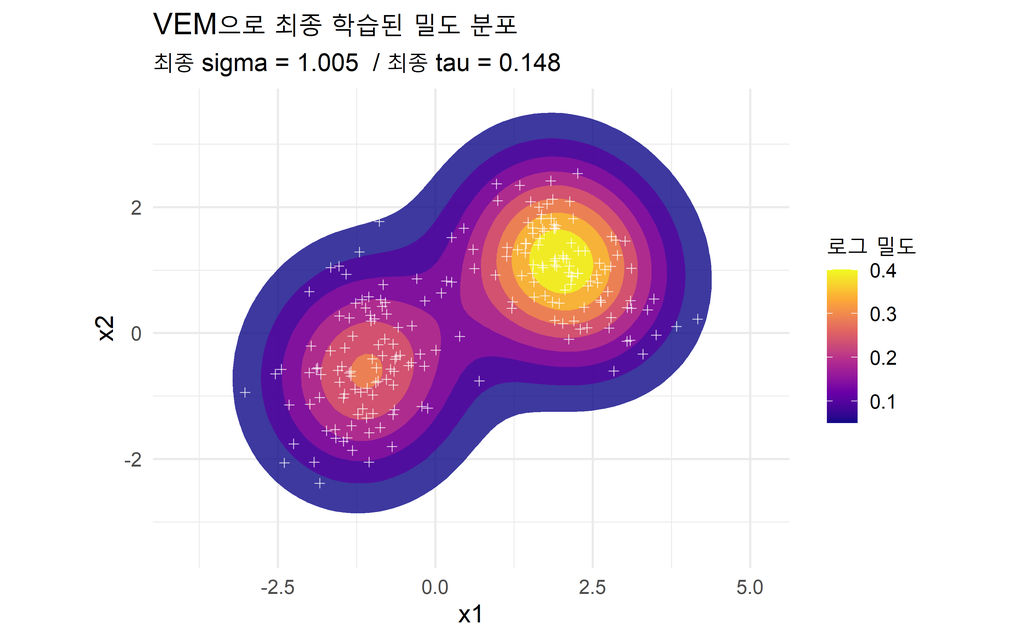

```r
# 최종 추정된 밀도 플롯
grid_range <- apply(X_data, 2, function(x) range(x) + c(-1, 1))
x1_grid <- seq(grid_range[1,1], grid_range[2,1], length.out = 80)
x2_grid <- seq(grid_range[1,2], grid_range[2,2], length.out = 80)
eval_grid <- expand.grid(x1 = x1_grid, x2 = x2_grid)

final_m <- vem_results$m
final_sigma <- vem_results$final_params[1]
log_density_vals <- apply(eval_grid, 1, function(x_eval) {
  phi_x <- sapply(1:nrow(basis_pts), function(j) rbf_kernel(x_eval, basis_pts[j,], final_sigma))
  sum(final_m * phi_x)
})
eval_grid$log_density <- log_density_vals

ggplot() +
  stat_contour(data = eval_grid, aes(x = x1, y = x2, z = log_density, fill = ..level..), geom = "polygon", alpha=0.8) +
  geom_point(data = dat, aes(x = x1, y = x2), alpha = 0.7, size = 1.5, shape=3, color="white") +
  scale_fill_viridis_c(option = "plasma") +
  coord_equal(xlim = grid_range[,1], ylim = grid_range[,2]) +
  labs(title = "VEM으로 최종 학습된 밀도 분포",
       subtitle = paste("최종 sigma =", round(final_sigma, 3), " / 최종 tau =", round(vem_results$final_params[2], 3)),
       x = "x1", y = "x2", fill = "로그 밀도") +
  theme_minimal(base_size = 14)
```

## 6 **5. 결론 (Conclusion)**

본 문서는 커널 밀도 추정에서 계산 비용이 많이 드는 교차 검증을 대체하기 위한 대안으로, 변분 기댓값-최대화(VEM) 기반의 완전 자동화 프레임워크를 제시했다. 스코어 매칭, 계층적 베이지안 모델링, 변분 추론을 결합하여, 커널 대역폭과 정규화 강도 같은 핵심 하이퍼파라미터를 데이터로부터 직접 학습하는 원칙적인 방법을 유도하고 R로 구현하였다.